# Plotting in R

## 1. Plotting systems

There are three different plotting systems in R, and they each have different characteristics and modes of operation. These three systems are the base plotting system, the lattice system, and the ggplot2 system.

### 1.1 The Base Plotting System

The base plotting system is the origial plotting system for R. The basic model is sometimes referred to as the “artist’s palette” model. The idea is you start with blank canvas and buid up from there by piecemeal.

It typically requires two steps to create a plot:

1. *initiate* a plot with a plotting function, such as `plot`, `boxplot`, `hist`
2. *annotate* the plot with various annotation functions (`text`, `lines`, `points`, `axis`)

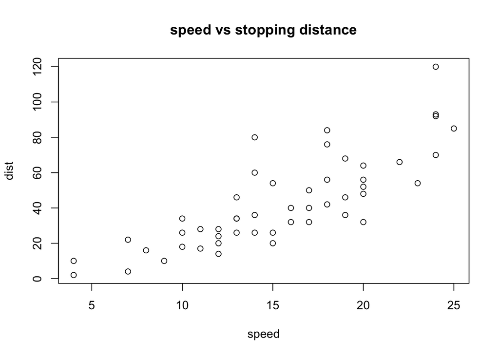

```r
data(cars)
## initiate
with(cars, plot(speed, dist))

## annotate
title("speed vs stopping distance")
```

### 1.2 The Lattice System

The lattice plotting system is implemented in the `lattice` package which comes with every installation of R (although it’s not loaded by default). To use the lattice plotting functions, you must first load the `lattice` package with the `library` function.

With the lattice system, plots are created in a *single* function, such as `xyplot` or `bwplot`. There is no such distinction as initiation vs annotation as using the base plotting system, because it all happens at once. This will of course sometimes complicate the syntax, but it also allows the margins and spacing to be set automatically. (Since all the information needed is available at one time.)

Lattice plots tend to be most useful for conditioning types of plots, i.e. looking at how y changes with x across levels of z, or plots by panel. These types of plots are useful for looking at multi-dimentional data and ofthen allow you to squeeze a lot of information into a single window or page.

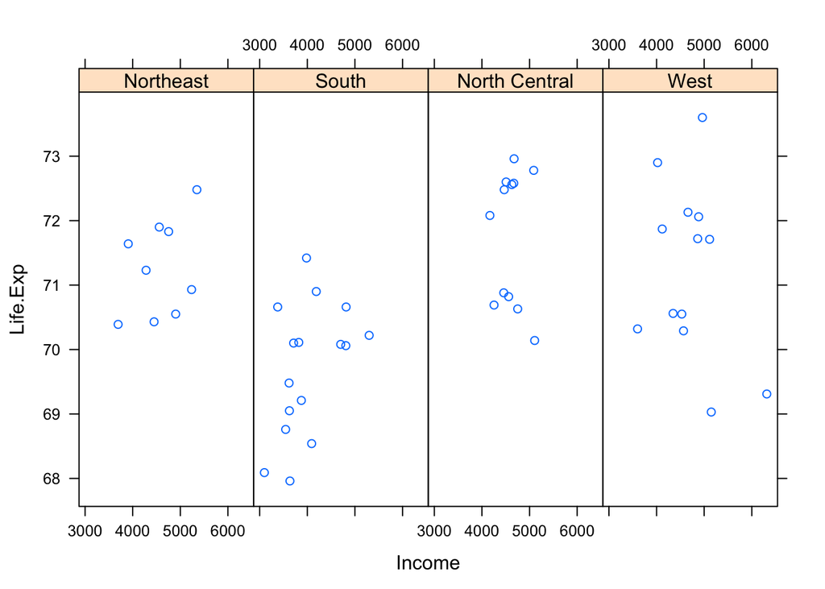

```r
library(lattice)
state <- data.frame(state.x77, region = state.region)
xyplot(Life.Exp ~ Income | region, data = state, layout = c(4, 1))
```

### 1.3 The ggplot2 System

The ggplot2 plotting system is an implementation of *The Grammar of Graphics* as described by Leland Wilkinson in his book. The package was originally written by Hadley Wickham while he was a graduate student at Iowa State University (he still actively maintains the package).

The grammar of graphics represents an abstraction of graphics ideas and objects. “The grammar tells us that a statistical graphic is a *mapping* from **data** to **aesthetic** attributes (color, shape, size) of **geometric** objects (points, lines, bars). The plot may also contain statistical transformations of the data and is drawn on a specific coordinate system.”

The ggplot2 system is implemented in the `ggplot2` package. It does not come with R. You can install from CRAN and load into R via `library()`.

Superficially, the ggplot2 functions are similar to lattice, but the system is generally easier and more intuitive to use.

## 2. Plotting devices

### 2.1 What is a graphics device

A graphics device is something where you can make a plot appear. When you make a plot in R, it has to be “sent” to a specific graphics device. Otherwise, there’s no way for it to be generated.

- A window on your compute (screen device)
- A PDF file (file device)
- A PNG or JPEG file (file device)
- A scalable vector graphics (SVG) file (file device)

The most common place for a plot to be “sent” is the *screen device*.

- On a Mac the screen device is launched with the `quartz()`.
- On Windows the screen device is launched with `windows()`
- On Unix/Linux the screen device is launched with `x11()`.

The list of devices is found in **?Devices**. There are also devices created by users on CRAN.

- For quick visualizations and exploratory analysis, usually you want to use the screen device. On a given platform (Mac, Windows, Unix/Linux) there is only one screen device.
- For plots that may be printed out or incorporated into a document, usually a file device is more appropriate.

### 2.2 How does a plot get generated

#### 2.2.1 Using screen device

1. Call a plotting function like `plot`, `xyplot`, or `qplot`
2. The plot appears on the screen device
3. Annotate the plot if necessary

#### 2.2.2 Using file device

1. Explicitly launch a graphics device
2. call a plotting function to make a plot (Note: if you are using a file device, no plot will appear on the screen)
3. Annotate the plot if necessary
4. Explicitly close graphics device with `dev.off()` (very important!)

```r
## Open PDF device and create 'test.pdf' in my working direcotry
pdf(file = "test.pdf")

## create plot and send to a file
with(faithful, plot(eruptions, waiting))

## Close the PDF device
dev.off()
```

### 2.3 Types of file devices

There are two basic types of file devices: vector and bitmap devies.

#### 2.3.1 Vector formats

- **pdf**: useful for line-type graphics, resizes well, usually portable, not efficient if a plot has many objects/points
- **svg**: XML-based scalable vector graphics; supports animation and interactivity, potentially useful for web-based plots; popular for web-based graphics.
- **win.metafile**: Windows metafile format (only on Windows)
- **postscript**: older format, also resizes well, usually portable, can be used to create encapsulated postscript files; Windows system often don’t have a postscript viewer.

#### 2.3.2 bitmap formats

Bitmap formats represent plots in a series of pixels essentially.

- **png**: stands for portable network graphics, good for line drawings or images with solid colors, uses lossless compression (like the old GIF format), most web browsers can read this format natively, good for plotting many many many points, does not resize well
- **jpeg**: good for photographs or natural scenes, uses lossy compression, good for plotting many many many points, does not resize well, can be ready by almost any computer and any web browser, not great for line drawings
- **tiff**: creates bitmap files in the TIFF format; supports lossless compression
- **bmp**: a native Windows bitmapped format

### 2.4 Multiple open graphics devices

It is possible to open multiple graphics devices (screen, file, or both), for example when viewing multiple plots at once. For example, you can launch screen devices on a Mac by calling the `quartz()` function multiple times.

- Plotting can only occcur on one device at time
- The currently active device can be found by calling `dev.cur()`
- Every open device is assigned an interger >= 2
- You can change the active device with `dev.set(<integer>)`.

## 3. Plotting and Color in R

R allows you to specify colors for your output in multiple ways, all of which follow the `col` command, which is short for “color” or “colour”. For example, all five of these methods refer to the same shade of red:

- Color name: `col = "red3"`
- Hex code: `col = "#CD0000"`
- RGB(0-255): `col = rgb(205, 0, 0. max = 255)`
- RGB(0.00-1.00): `col = rgb(.80, .00, .00)`
- Index number: `col = colors()[555]`

### 3.1 basics

In R, the color black is denoted by `col = 1` in most plotting functions, red is denoted by `col = 2`, and green is denoted by `col = 3`. If you are plotting multiple groups of things, it’s natural to plot them using colors 1, 2, and 3.

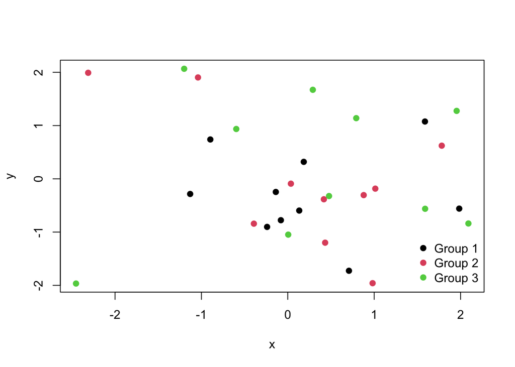

```r
set.seed(2)
x <- rnorm(30)
y <- rnorm(30)
plot(x, y, col = rep(1:3, each = 10), pch = 19)
legend("bottomright", legend = paste("Group", 1:3), col = 1:3, pch = 19, bty = "n")
```

Here is another set of common color schemes used in R.

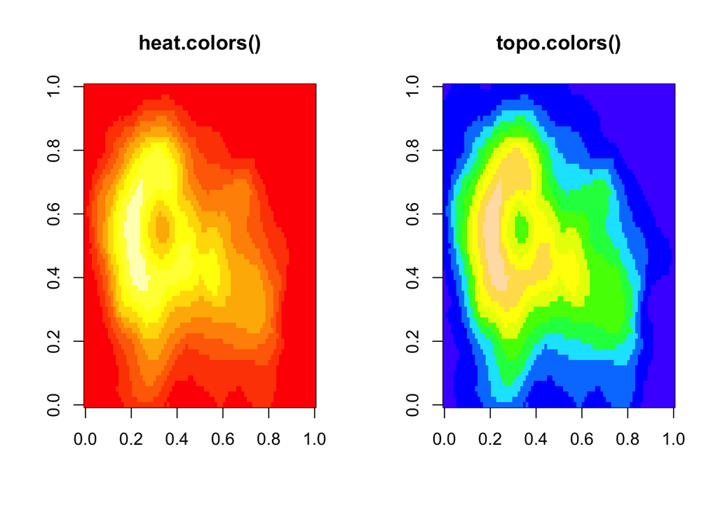

```r
par(mfrow = c(1, 2)) ## 1 x 2 pictures on the plotting region
image(volcano, col = heat.colors(10), main = "heat.colors()")
image(volcano, col = topo.colors(10), main = "topo.colors()")
```

### 3.2 more advanced color utilities in R

R has a number of utilities for dealing with colors and color palettes. For starters, the `grDevices` package has two functions:

- `colorRamp()`: Take a palette of colors and return a function that takes values between 0 and 1, indicating the extremes of the color palette (e.g. see the `gray()` function)
- `colorRampPalette()`: Take a palette of colors and return a function that takes integer arguments and returns a vector of colors interpolating the paletter (lke `heat.colors()` or `topo.colors()`)

#### 3.2.1 `colorRamp()`

```
> pal <- colorRamp(c("red", "blue"))
> ## red
> pal(0)
     [,1] [,2] [,3]
[1,]  255    0    0
> ## blue
> pal(1)
     [,1] [,2] [,3]
[1,]    0    0  255
> ## purple-ish
> pal(0.5)
      [,1] [,2]  [,3]
[1,] 127.5    0 127.5
```

Notice that `pal` is a function returned by `colorRamp()`. When we call `pal(0)` we get a 1 by 3 matrix. The numbers in the matrix range from 0 to 255 indicating the quantities of red, green, and blue (RGB) in columns 1, 2, and 3, respectively.

Simple math tells us there are over 16 million colors that can be expressed this way.

You can also pass a sequence of numbrers to `pal()`.

```
> pal(seq(0, 1, len = 10))
           [,1] [,2]      [,3]
 [1,] 255.00000    0   0.00000
 [2,] 226.66667    0  28.33333
 [3,] 198.33333    0  56.66667
 [4,] 170.00000    0  85.00000
 [5,] 141.66667    0 113.33333
 [6,] 113.33333    0 141.66667
 [7,]  85.00000    0 170.00000
 [8,]  56.66667    0 198.33333
 [9,]  28.33333    0 226.66667
[10,]   0.00000    0 255.00000
```

Note that you do not have to provide just two colors in your initial color palette; you can start with multiple colors, and `colorRamp()` will interpolate between all of them.

#### 3.2.2 `colorRampPalette()`

The `colorRampPalette()` function in manner similar to `colorRamp()`, however the function that it returns takes an integer argument and gives you a fixed number of colors that interpolate the palette.

```
> pal <- colorRampPalette(c("red", "yellow"))
> ## Just return red and yellow
> pal(2)
[1] "#FF0000" "#FFFF00"
```

Note that the colors are represented as hexadecimal strings. After terh # symbol, the first two characters indicate the red amount, the second two the green amount, and the last two the blue amount. Because each position can have 16 possible values (0-9 and A-F), the two positions together allow for 256 possibilities per color.

We can ask for more:

```
> ## return 10 colors between red and yellow
> pal(10)
 [1] "#FF0000" "#FF1C00" "#FF3800" "#FF5500" "#FF7100" "#FF8D00" "#FFAA00" "#FFC600" "#FFE200" "#FFFF00"
```

### 3.3 RColorBrewer Package

Part of the art of creatng good color schemes in data graphics is to start with an appropriate color palette that you can then interpolate with a function like `colorRamp()` or `colorRampPalette()`. One additional package that contains interesting and useful color palettes is the `RColorBrewer` package.

The `RColorBrewer` package offers three types of palettes:

- Sequential: for numeric data that are ordered
- Diverging: for numeric data that can be positive or negative, often representing deivations from some norm or baseline
- Qualitative: for qualitative unordered data

All of these palettes can be used in conjunction with `colorRamp()` and `colorRampPalette()`.

Here is a display of all the color palettes available from the `RColorBrewer` package.

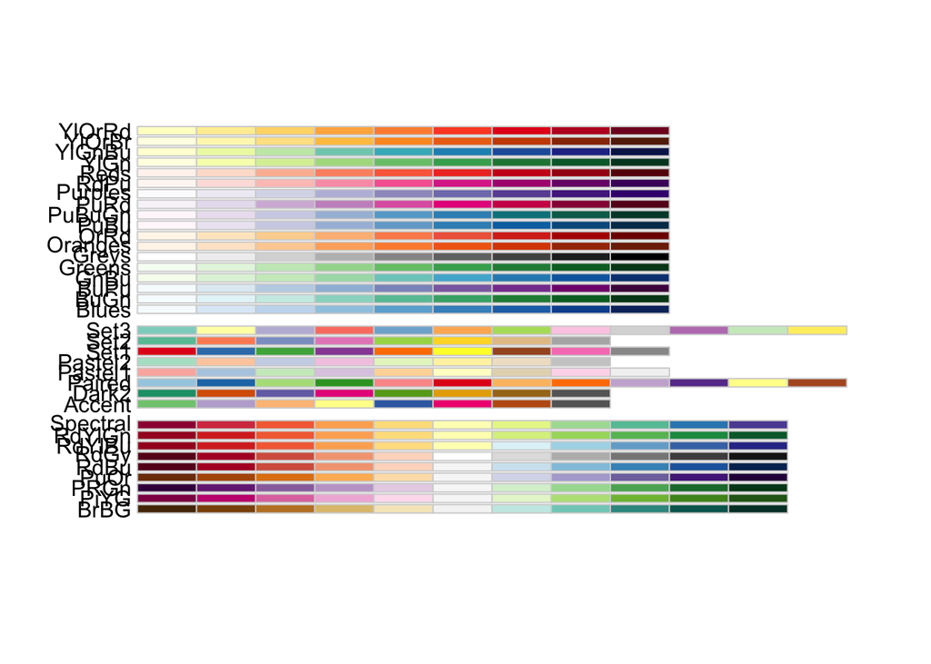

```r
library(RColorBrewer)
display.brewer.all()
```

#### 3.3.1 Using the RColorBrewer palettes

The only real function in the `RColorBrewer` package is the `brewer.pal` function which has two arguments: - `name`: the name of the color palette you want to use - `n`: the number of colors you want from the palette (integer)

```r
library(RColorBrewer)
## use three colors from RdPu
cols <- brewer.pal(3, "RdPu")
cols
```

```
## [1] "#FDE0DD" "#FA9FB5" "#C51B8A"
```

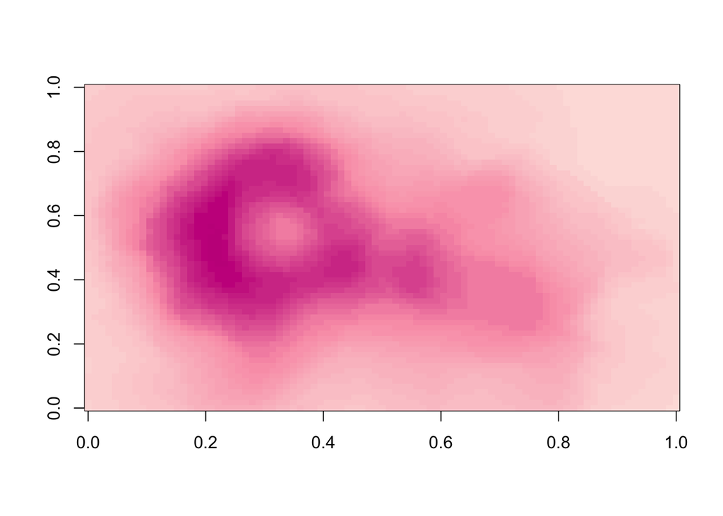

```r
## Pass the color palette to colorRampPalette()
pal <- colorRampPalette(cols)
## Plot 'volcano' data
image(volcano, col = pal(30))
```

#### 3.3.2 The `smoothScatter()` function

A function that takes advantage of the color palettes in `RColorBrewer` is the `smoothScatter()` function, which is very useful for making scatterplots of very large datasets.

The `smoothScatter()` function essentially gives you a 2-D histogram of the data using a sequential palette.

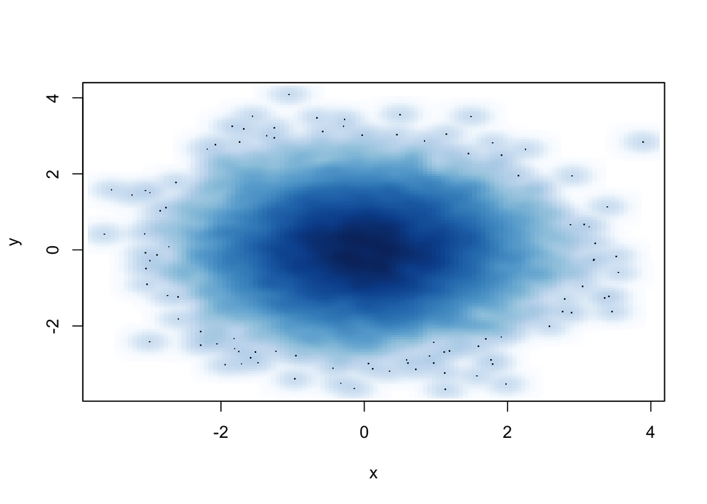

```r
set.seed(3)
x <- rnorm(10000)
y <- rnorm(10000)
smoothScatter(x, y)
```

### 3.4 Transparency - `rgb()`

Color transparency can be added via the `alpha` parameter to `rgb()` to produce color specifications with varying levels of transparency.

When transparency is used, you’ll notice an extra two characters added to the right side of the hexadecimal representation. For example, if I wanted the color read with a high level of transparency, I could specify

```
> rgb(1, 0, 0, 0.1)
[1] "#FF00001A"
```

Transparency can be useful when you have plots with a high density of points or lines.

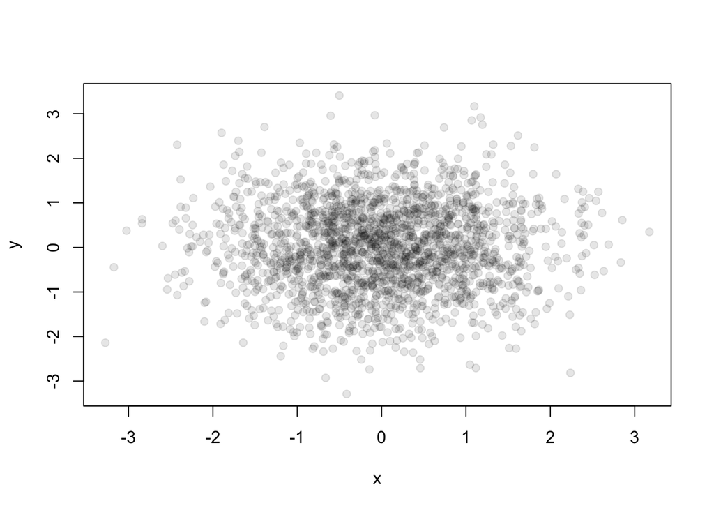

```r
set.seed(4)
x <- rnorm(2000)
y <- rnorm(2000)
plot(x, y, pch = 19, col = rgb(0, 0, 0, 0.1))
```